# Quadratic function

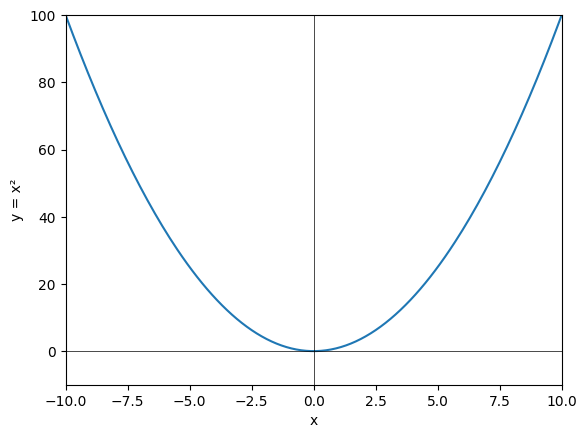

```python
plot_quadratic(xs, ylim=(-10, 100), ylabel='y = x²'); plt.show()
```

## Quadratic's function derivative

- Quadratic: $f(x) = x^2$
- Derivative: $f'(x) = 2x$
  - Slope of the tangent line at a given point of $f(x)$.
- Slope: change on $f(x)$ for each unit of $x$.
  - The higher the slope, the higher the rate of change.
  - Negative slopes mean downward trend.
  - Positive slopes mean upward trend.
  - Slope of 0 means no change. E.g., minimum in quadratic functions.

```
Point: (1, 1)
Slope: 2
```

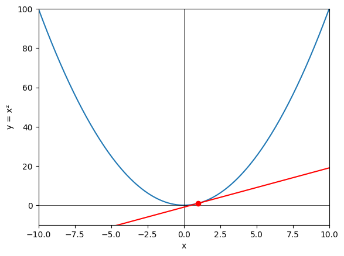

```python
plot_with_slope(x=1)
plt.show()
```

```
Point: (-3, 9)
Slope: -6
```

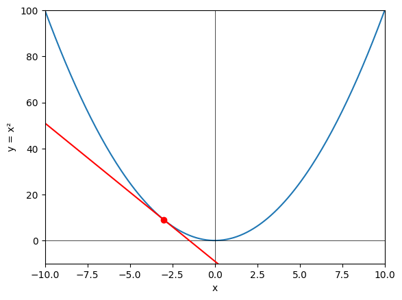

```python
plot_with_slope(x=-3)
plt.show()
```

```
Point: (8, 64)
Slope: 16
```

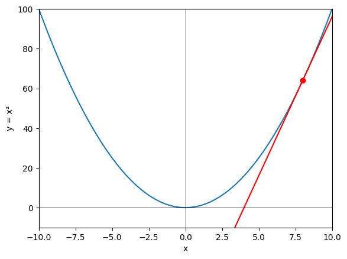

```python
plot_with_slope(x=8)
plt.show()
```

```
Point: (0, 0)
Slope: 0
```

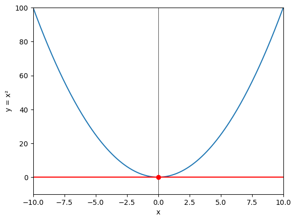

```python
plot_with_slope(x=0)
plt.show()
```

- Quadratic functions can have a lot of different shapes and positions.

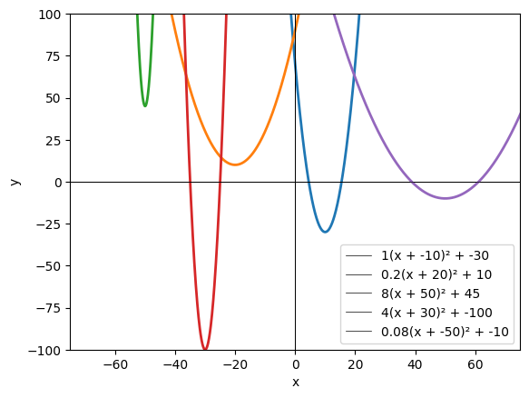

```python
plot_quadratics()
```

# Gradient Descent

- It is easy to find the minimum if we plot a quadratic function.
- We can also calculate the minimum using some calculus and algebra.
- But what if it was computationally intensive to plot or calculate the minimum?
- Given a point on the function, how can we find the global minimum?

```
Point: (28, -216)
```

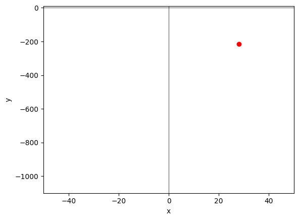

```python
plot_hidden_quadratic(x=28)
plt.show()
```

- A priori we don't know the shape of the parabola.
- Could be anything.

```
Point: (28, -216)
```

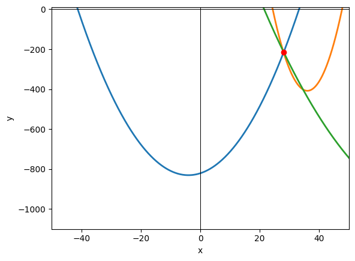

```python
plot_quad_crossings()
```

- We can compute the slope, that is easy.
- Now we know we are still a bit far from the minimum.
- We also know we are on the right side of the parabola.

```
Point: (28, -216)
Slope: 56
```

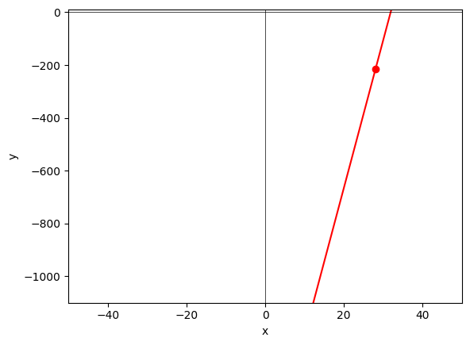

```python
plot_hidden_quadratic(x=28, show_slope=True); plt.show()
```

- One option for finding the minimum would be to apply the gradient descent.
- It consists in iterating and updating the value of $x$.
- $x_{\text{new}} = x_{\text{old}} - \alpha \cdot \nabla_{x} f(x)$, where
  - $x_{\text{old}}$ is the current $x$ value.
  - $x_{\text{new}}$ is the new $x$ value after the update.
  - $\alpha$ is the learning rate. Defines how fast we update $x$.
  - $\nabla_{x} f(x)$ is the gradient of the function. It is the slope in our example.

```
Initial Point: (28, -216)
Initial Slope: 56

Iteration 1: x_new = x_old - 0.1 * 44.8 = 22.4
New point: (x = 22.4, y = -498.2)
New slope: 44.8

Iteration 2: x_new = x_old - 0.1 * 35.8 = 17.9
New point: (x = 17.9, y = -679.6)
New slope: 35.8

Iteration 3: x_new = x_old - 0.1 * 28.6 = 14.3
New point: (x = 14.3, y = -795.5)
New slope: 28.6

Iteration 4: x_new = x_old - 0.1 * 22.8 = 11.4
New point: (x = 11.4, y = -870.0)
New slope: 22.8

Iteration 5: x_new = x_old - 0.1 * 18.2 = 9.1
New point: (x = 9.1, y = -917.2)
New slope: 18.2

Point: (9.1, -917.2)
Slope: 18.2
```

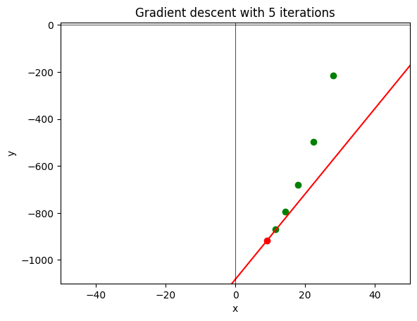

```python
plot_hidden_quadratic(x=28, show_slope=True, iters=5,
                      learning_rate=0.1)
plt.show()
```

```
Initial Point: (28, -216)
Initial Slope: 56

Point: (0.2, -1000.0)
Slope: 0.4
```

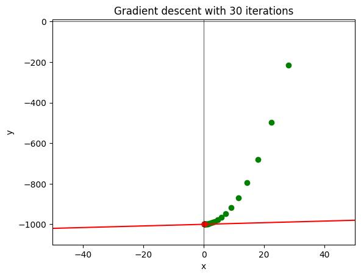

```python
plot_hidden_quadratic(x=28, show_slope=True, iters=30,
                      learning_rate=0.1, verbose=False); plt.show()
```

- Take care with the choice of the learning rate!
- Large values will bounce between the "two slopes" of the quadratic function:
  - It can take more time until convergence.
  - Or it may never converge.
- Low learning rates will take longer to converge.
  - Although it will finally arrive at some point.
  - Or not if the function has more than 1 minima.

```
Initial Point: (28, -216)

Point: (10.9, -881.2)
```

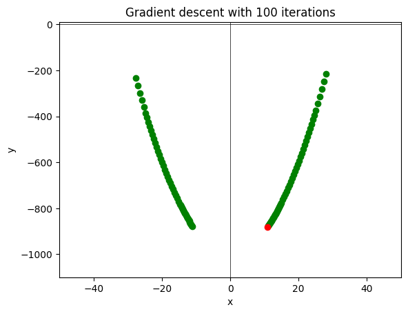

```python
plot_hidden_quadratic(x=28, show_slope=False, iters=100,
                      learning_rate=0.995, verbose=False); plt.show()
```

```
Initial Point: (28, -216)

Point: (3.1, -990.4)
```

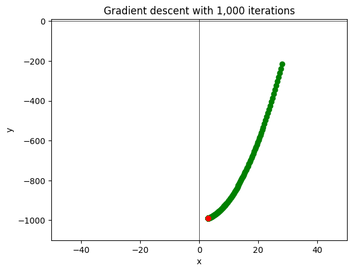

```python
plot_hidden_quadratic(x=28, show_slope=False, iters=1_000,
                      learning_rate=0.008, verbose=False); plt.show()
```

# Linear Regression

- Assume we have a single feature $x$.
- Linear Regression prediction:
  - $\hat{y}_i = w_0 + w_1 \cdot x_i$
- We said LR optimizes $MSE$.
- $MSE = \frac{1}{N} \sum{(\hat{y}_i - y_i)^2}$
- Because $MSE$ is a quadratic function wrt the coefficients $w_n$.
- $MSE = \frac{1}{N} \sum{( w_0 + w_1 \cdot x_i - y_i)^2}$

```python
df = pd.DataFrame({
    'm2': [50, 80, 100, 120, 150, 200],
    'price': [60000, 96000, 100000, 130000, 140000, 199000]
})
df
```

|  | m2 | price |
| --- | --- | --- |
| 0 | 50 | 60000 |
| 1 | 80 | 96000 |
| 2 | 100 | 100000 |
| 3 | 120 | 130000 |
| 4 | 150 | 140000 |
| 5 | 200 | 199000 |

```python
# m2
x = df['m2'].values

# euros
y = df['price'].values
```

- Liner Regression finds the coefficients $w_i$ that optimize $MSE$:
  - $\hat{y}_i = w_0 + w_1 \cdot x_i$
- Assume for the sake of the example that we know the optimal $w_0$ is $0$.
- Can we find the value of $w_1$ that gives the best $MSE$?
- Yes! For example, by applying gradient descent!
- We can start with a random $w_1$ and descend until convergence.

```python
w1 = -3894
```

- We know $w_0 = 0$.
- And we have set a random $w_1 = -3894$.
- We can now calculate all the predictions $\hat{y}_i = w_0 + w_1 \cdot x_i$.
- Based on the $x_i$ (house square meters) of our dataframe.
- As we can calculate the predictions $\hat{y}$, we can calculate the $MSE$.
  - $MSE = \frac{1}{N} \sum{(\hat{y}_i - y_i)^2}$
- We have a bad prediction (magenta) because we selected $w_1$ randomly.
- Our $MSE$ (red dot) is sky high.
- We don't know the shape of our quadratic $MSE$,
- But we can calculate the slope.
- And apply gradient descent:
  - $w_1 = w_1 - \alpha \cdot \nabla_{w_1} MSE$

```
w1: -3894
Slope: -156,708,400
```

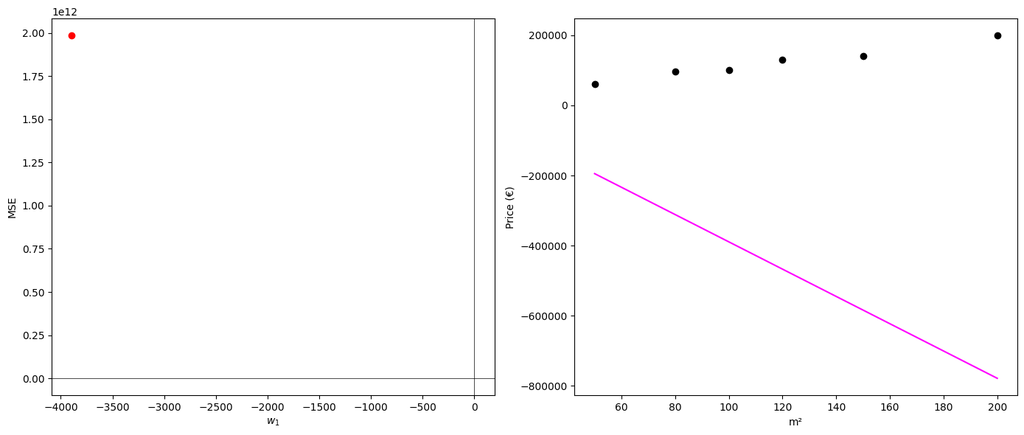

```python
plot_lr_mse()
```

```python
learning_rate = 0.00001
```

```
New w1: -2326.916
Slope: -106,666,184
```

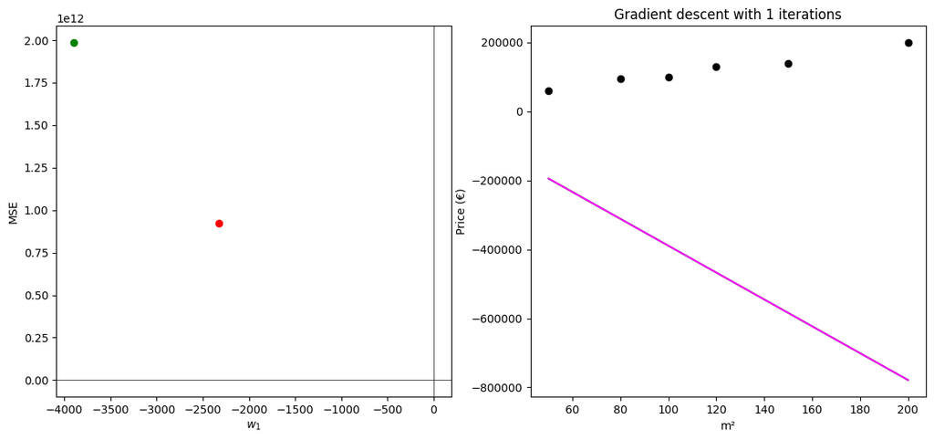

```python
w1 = plot_lr_gd(w1, x, y)
```

```
New w1: -1260.2541573333335
Slope: -72,604,116
```

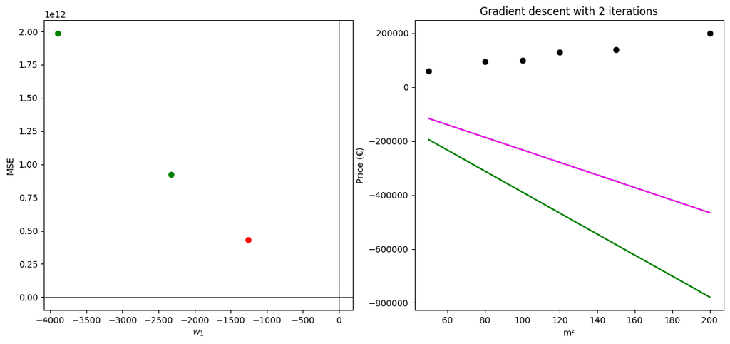

```python
w1 = plot_lr_gd(w1, x, y)
```

```
New w1: -534.212996424889
Slope: -49,419,201
```

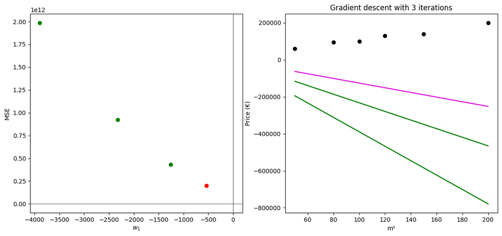

```python
w1 = plot_lr_gd(w1, x, y)
```

```
New w1: -40.02097956654109
Slope: -33,638,003
```

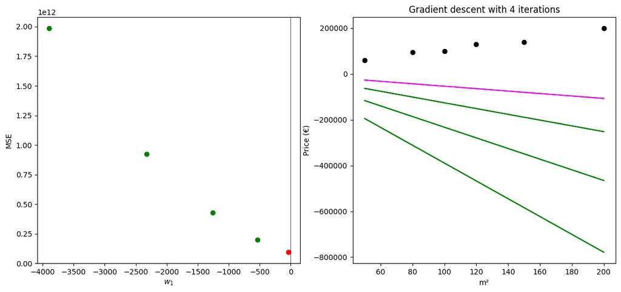

```python
w1 = plot_lr_gd(w1, x, y)
```

```
New w1: 980.3244963426528
Slope: -1,054,971
```

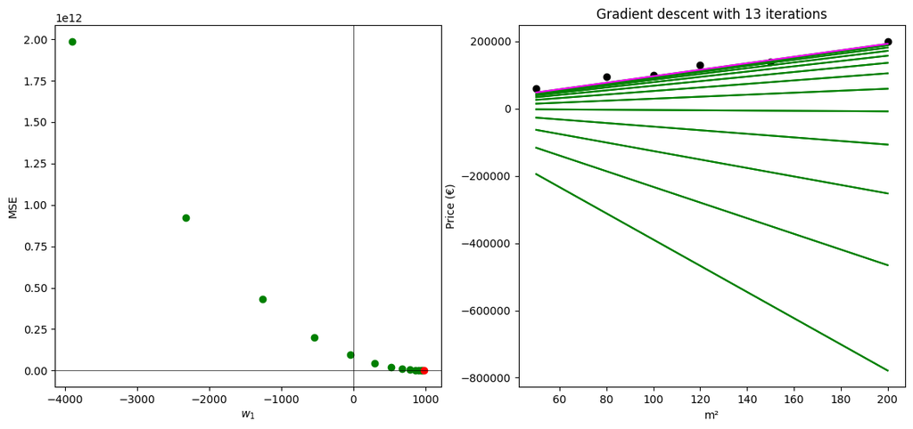

```python
w1 = plot_lr_gd(w1, x, y)
```

# Optimize $w_0$ and $w_1$

- Previously, for simplicity, we assumed $w_0 = 0$ and optimized $w_1$.
- If we want to optimize the whole line equation,
  - $w_0$ and $w_1$,
- Gradient descent works the same but in 3D, with axis: $w_0$, $w_1$, and $MSE$.

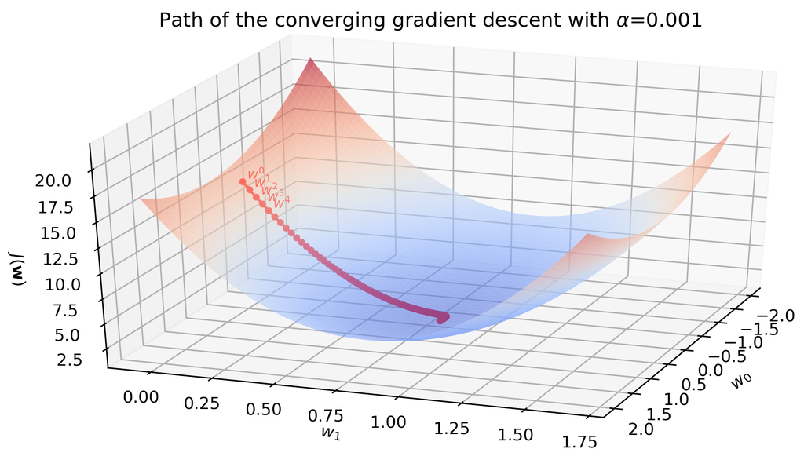

```python
Image('assets/GD_w0_w1.png', width=800)
```

# Gradient Descent for $w_N$

- Initialize "random" weights $w_N$: one for each feature plus $w_0$.
- Loop until convergence or max. iterations reached:
  - Perform predictions.
    - $\hat{y} = w_0 + w_1x_1 + w_2x_2 + ... + w_nx_n$ (in the case of LR)
  - Compute loss (e.g., MSE or Logloss).
    - $MSE = \frac{1}{N} \sum{(\hat{y}_i - y_i)^2}$
  - Calculate gradient (i.e., derivative of loss wrt each $w_i$).
  - Update $w_i$:
    - $w_i = w_i - \alpha \cdot \nabla_{w_i} MSE$

# Vectorized Form

- Computationally more efficient.
- It's the same as above but using linear algebra.
- Given a matrix of features $X$.
- Initialize "random" vector of weights $\mathbf{w}$.
- Loop until convergence or max. iterations reached:
  - Compute vector of predictions $\hat{\mathbf{y}}$.
    - $\hat{\mathbf{y}} = w_0 + X \mathbf{w}$ (in the case of LR)
  - Compute loss (e.g., MSE or Logloss).
    - $MSE = \frac{1}{N} \sum{(\hat{y}_i - y_i)^2}$
  - Calculate gradient $\nabla_{\mathbf{w}} MSE$.
  - Update $\mathbf{w}$:
    - $\mathbf{w} = \mathbf{w} - \alpha \cdot \nabla_{\mathbf{w}} MSE$

# Types of GD

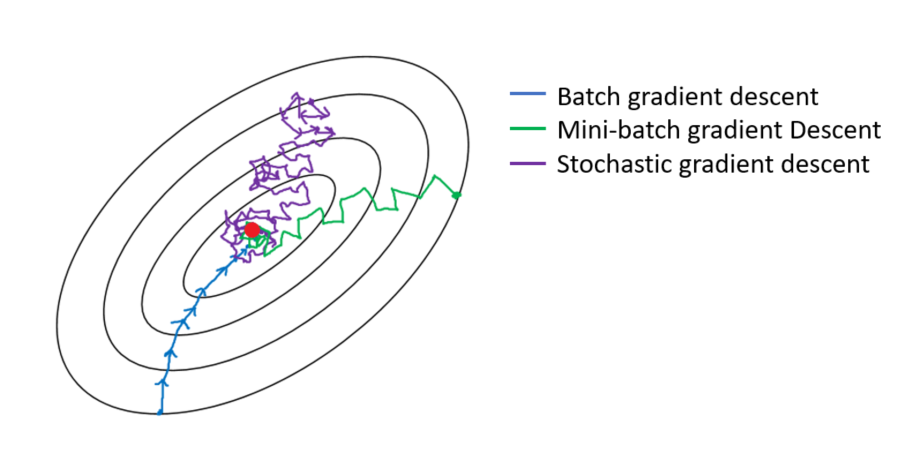

```python
Image('assets/types_gd.png', width=800)
```

## Batch GD

- Until convergence or max. iterations:
  - Calculate error for each sample in the train set.
  - Update weights after evaluating all training samples.
- Pros:
  - Stable convergence.
  - Consistent gradient.
- Cons:
  - Computationally intensive.
  - Prone to getting stuck in local minima.

## Stochastic GD

- Until convergence or max. iterations:
  - For each sample in the train set:
    - Calculate error for a single sample.
    - Update weights based on this sample.
- Pros:
  - Fast updates.
  - Potential local minima scape.
- Cons:
  - Noisy convergence.
  - Inconsistent gradient.

## Mini-batch GD

- Split train set into small batch sizes (mini-batches).
- Until convergence or max. iterations:
  - Apply batch GD on each mini-batch.
- Mixed Pros and Cons of batch and stochastic GD.

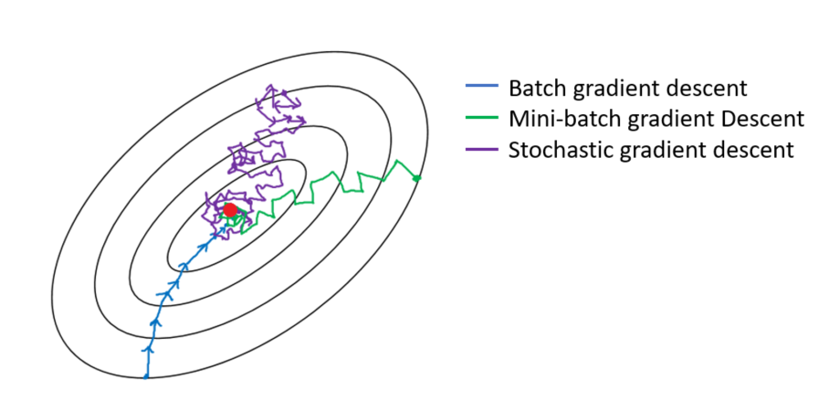

```python
Image('assets/types_gd.png', width=800)
```